# Examples

### Apply trained ML flow rule in FEA

After the successful training of the ML yield function, it can be applied directly in FEA. Its gradients of can be calculated directly from the coefficients and the support vectors resulting from the training process. The following code segment, demonstrates the application of the ML yield function in the pyLabFEA module. First, a model with two sections is generates, where section 1 is assigned to the reference material `mat1` and section 2 is assigned to `mat2` with the ML yield function.

```
==========================================
=== FEA with reference and ML material ===
==========================================
Global strain:  [-0.0017  0.004  -0.001   0.      0.     -0.    ]
Element strain (ref):  [-0.0016  0.004  -0.001   0.      0.      0.    ]
Element strain (ML):  [-0.0018  0.004  -0.0009  0.      0.     -0.    ]
Global stress:  [  0.     162.4935   0.       0.       0.      -0.    ]
Element stress (ref):  [  0.     162.5794   0.       0.       0.       0.    ]
Element stress (ML):  [  0.     162.4076   0.       0.       0.      -0.    ]
Global plastic strain:  [-0.00175  0.00308 -0.00134  0.       0.       0.     ]
Plastic strain (ref):  [-0.0016   0.00311 -0.00151  0.       0.       0.     ]
Plastic strain (ML):  [-0.00189  0.00306 -0.00116  0.       0.       0.     ]
----------------------------
Material 1 (left block):   {'yield_fct': 'analytical', 'gradient': 'analytical'}
Material 2 (right block):  {'yield_fct': 'ML_yf-decision-fct', 'gradient': 'gradient to ML_yf'}
```

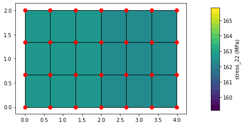

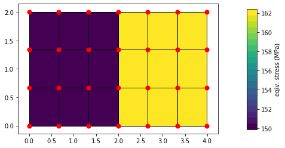

```
Note: Different definitions of SEQ for Hill and J2.
```

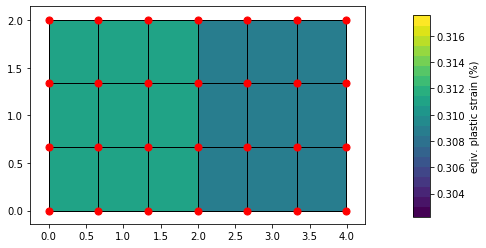

```python
fem=FE.Model(dim=2,planestress=True)
fem.geom([2, 2], LY=2.)  # define sections in absolute lengths

print('==========================================')
print('=== FEA with reference and ML material ===')
print('==========================================')
fem.assign([mat1, mat2])  # create a model with trained ML-flow rule (mat1) and reference material (mat3)
fem.bcleft(0.)
fem.bcbot(0.)
fem.bcright(0., 'force')   # free right edge
fem.bctop(0.004*fem.leny, 'disp')  # apply displacement at top nodes (uniax y-stress)
fem.mesh(NX=6, NY=3)
fem.solve()
fem.calc_global()
print('Global strain: ', np.round(fem.glob['eps'],decimals=4))
print('Element strain (ref): ', np.round(fem.element[0].eps,decimals=4))
print('Element strain (ML): ', np.round(fem.element[10].eps,decimals=4))
print('Global stress: ', np.round(fem.glob['sig'],decimals=4))
print('Element stress (ref): ', np.round(fem.element[0].sig,decimals=4))
print('Element stress (ML): ', np.round(fem.element[10].sig,decimals=4))
print('Global plastic strain: ', np.round(fem.glob['epl'],decimals=5))
print('Plastic strain (ref): ', np.round(fem.element[0].epl,decimals=5))
print('Plastic strain (ML): ', np.round(fem.element[10].epl,decimals=5))
print('----------------------------')
print('Material 1 (left block):  ',mat1.msg)
print('Material 2 (right block): ',mat2.msg)

fem.plot('stress2',mag=1)
fem.plot('seq',mag=1)
print('Note: Different definitions of SEQ for Hill and J2.')
fem.plot('peeq',mag=1)
```

Note that the element stresses in both materials are very similar (top figure). However, the different definitions of the Hill equivalent stress and the J2 equivalent stress produce a numerical difference in the plot of the equivalent stresses (middle figure). The resulting plastic strains in both sections are quite similar (bottom figure).

The second example applies the same four load cases under which the reference material has been characterized and compares the results.

```
====== Stress-Strain-Curves ======
==============================================================
J2 yield stress under uniax-x loading: 147.39267596379034 MPa
==============================================================
J2 yield stress under uniax-y loading: 161.51299710165046 MPa
==============================================================
J2 yield stress under equibiax loading: 138.53409225697783 MPa
==============================================================
J2 yield stress under shear loading: 160.25165667614655 MPa
==============================================================
```

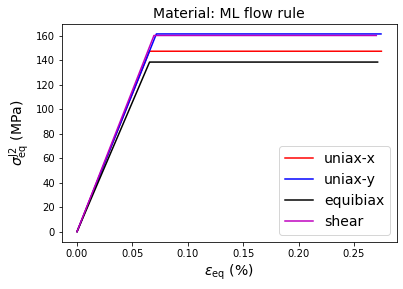

```
*** load case:  uniax-x
             Rel. error in yield strength :  0.69 %
Rel. error in plastic strain at max. load :  4.5600000000000005 %
*** load case:  uniax-y
             Rel. error in yield strength :  -0.73 %
Rel. error in plastic strain at max. load :  0.49 %
*** load case:  equibiax
             Rel. error in yield strength :  1.17 %
Rel. error in plastic strain at max. load :  -0.02 %
*** load case:  shear
             Rel. error in yield strength :  -0.54 %
Rel. error in plastic strain at max. load :  -0.4 %
```

```python
print('\n\n====== Stress-Strain-Curves ======')
mat2.calc_properties(verb=False, eps=0.003, min_step=10)
mat2.plot_stress_strain()  # file='sigJ2-eps-ML'
for sel in mat1.prop:
    print('*** load case: ',mat1.prop[sel]['name'])
    print('             Rel. error in yield strength : ',
          100*np.round(mat2.propJ2[sel]['ys']/mat1.propJ2[sel]['ys']-1.,decimals=4),'%')
    mpl_ref = np.amax(mat1.propJ2[sel]['peeq'])
    mpl_ml1 = np.amax(mat2.propJ2[sel]['peeq'])
    print('Rel. error in plastic strain at max. load : ',
         100*np.round(mpl_ref/mpl_ml1-1.,decimals=4),'%')
```

## Train ML yield function with results of 4 load cases

In the following, the training data is created only from the four load cases of the reference material. For all load cases $\sigma_3=0$, yet due to the data-oriented formulation of the yield function on the deviatoric plane, a full yield function can be achieved. A new material `mat3` is created on which the ML training is performed.

```
Plot theta vs. J2 eqiv. stress curves for ML material
```

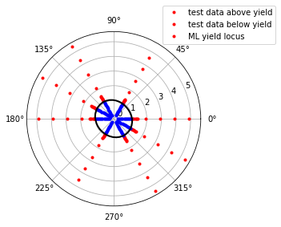

```
-------------------------

SVM classification fitted
-------------------------

SVC(C=10, break_ties=False, cache_size=200, class_weight=None, coef0=0.0,
    decision_function_shape='ovr', degree=3, gamma=4.0, kernel='rbf',
    max_iter=-1, probability=False, random_state=None, shrinking=True,
    tol=0.001, verbose=False)
Training data points (only polar angle): 36 , Test data points: 20
Training set score: 99.28571428571429 %
Test set score: 99.16666666666667 %
r^2 on test data : 0.965942
Plot of yield locus and training data in slices of 3D principle stress space
```

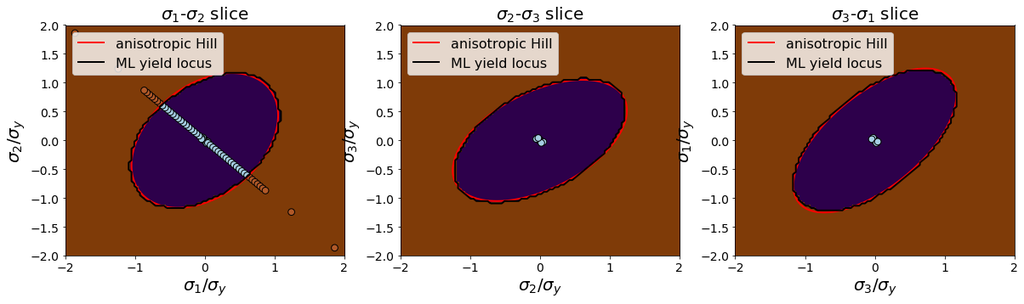

```python
'get principle yield stresses of 4 load cases from reference material'
sig=np.zeros((4,3))
i=0
for sel in mat1.sigeps:
    peeq = FE.eps_eq(mat1.sigeps[sel]['epl'])
    iys = np.nonzero(peeq<1.e-6)  # take stress at last index of elastic regime
    ys = mat1.sigeps[sel]['sig']
    sp_yld = FE.Stress(ys[iys[0][-1]]).p
    sig[i,:] = sp_yld
    i += 1

'mirror data in theta space: tension-compression symmetry'
sc1 = FE.s_cyl(sig)
sc2 = np.zeros((4,3))
sc2[:,0] = sc1[:,0]
sc2[:,1] = sc1[:,1]-np.pi
sc2[:,2] = sc1[:,2]
sc = np.append(sc1,sc2,axis=0)
sig = FE.sp_cart(sc)

'expand stresses into elastic and plastic regimes'
offs = 0.01
x = offs*sig
N = 23
for i in range(N):
    hh = offs + (1.4-offs)*(i+1)/N
    x = np.append(x, hh*sig, axis=0)
# add training points in plastic regime to avoid fallback of SVC decision fct. to zero
x = np.append(x, 2.*sig, axis=0)
x = np.append(x, 3.*sig, axis=0)
x = np.append(x, 4.*sig, axis=0)
x = np.append(x, 5.*sig, axis=0)

'result data for training of ML yield function'
y = mat2.calc_yf(x, pred=True)

print('Plot theta vs. J2 eqiv. stress curves for ML material')
ind1 = np.nonzero(y<0.)
ind2 = np.nonzero(y>=0.)
sc = FE.s_cyl(x) # convert princ. stresses into cylindrical coordinates
plt.polar(sc[ind2,1],sc[ind2,0]/mat2.sy,'.r')
plt.polar(sc[ind1,1],sc[ind1,0]/mat2.sy,'.b')
'find norm of princ. stess vector lying on yield surface'
theta = np.linspace(0.,2*np.pi,36)
snorm = FE.sp_cart(np.array([mat2.sy*np.ones(36)*np.sqrt(3/2), theta]).T)
x1 = fsolve(mat2.find_yloc, np.ones(36), args=snorm, xtol=1.e-5)
hs = snorm*np.array([x1,x1,x1]).T
s_yld = mat2.calc_seq(hs)
plt.polar(theta, s_yld/mat2.sy, '-k', linewidth=2)
plt.legend(['test data above yield','test data below yield','ML yield locus'], loc=(0.78,0.93))
#plt.savefig('polar-J2.pdf', format='pdf', dpi=300)
plt.show()

'define material for training with new data'
mat3 = Material(name='ML-triax')
mat3.elasticity(E=E, nu=nu)
mat3.plasticity(sy=mat1.sy, hill=[1., 1., 1.], drucker=0., khard=0.)

'initialize and train SVC as yield function'
train_sc, test_sc = mat3.setup_yf_SVM(x, y, x_test=x_test, y_test=y_test,
                                      C=10, gamma=4., fs=0.3, plot=False)
y_pred_clf = mat3.calc_yf(x_test,pred=True)
r2_score_svm = r2_score(y_test, y_pred_clf)
print('\n-------------------------\n')
print('SVM classification fitted')
print('-------------------------\n')
print(mat3.svm_yf)
print("Training data points (only polar angle):", ndata,", Test data points:", ntest)
print("Training set score: {} %".format(train_sc))
print("Test set score: {} %".format(test_sc))
print("r^2 on test data : %f" % r2_score_svm)

print('Plot of yield locus and training data in slices of 3D principle stress space')
mat3.plot_yield_locus(mat3.calc_yf, label=['ML yield locus'], ref_mat=mat1, data=x, trange=3.e-2,
                      axis1=[0,1,2], axis2=[1,2,0], ref=False) #Nmesh=300,file='yield-fct-slices'
```

## Comparison of different training methods

The following code segment shows the same set of FE simulations as in the case of the yield function fitted to regular training data

```
==========================================
=== FEA with reference and ML material ===
==========================================
Global strain:  [-0.0017  0.004  -0.001   0.      0.     -0.    ]
Element strain (ref):  [-0.0016  0.004  -0.001   0.      0.      0.    ]
Element strain (ML):  [-0.0018  0.004  -0.0009  0.      0.     -0.    ]
Global stress:  [  0.     160.7215   0.       0.       0.      -0.    ]
Element stress (ref):  [  0.     162.5471   0.       0.       0.      -0.    ]
Element stress (ML):  [  0.     158.8959   0.       0.       0.      -0.    ]
Global plastic strain:  [-0.00176  0.00309 -0.00134  0.       0.       0.     ]
Plastic strain (ref):  [-0.0016   0.00311 -0.00151  0.       0.       0.     ]
Plastic strain (ML):  [-0.00191  0.00307 -0.00116  0.       0.       0.     ]
----------------------------
Material 1 (left section):   {'yield_fct': 'analytical', 'gradient': 'analytical'}
Material 3 (right section):  {'yield_fct': 'ML_yf-decision-fct', 'gradient': 'gradient to ML_yf'}
```

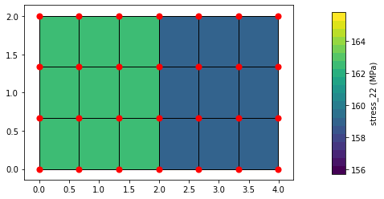

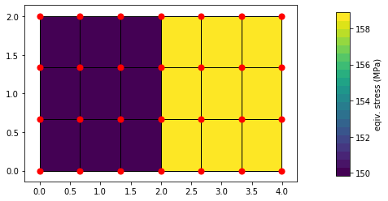

```
Note: Different definitions of SEQ for Hill and J2.
```

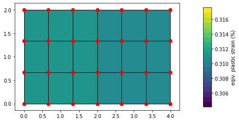

```
====== Stress-Strain-Curves ======
==============================================================
J2 yield stress under uniax-x loading: 147.4689467007472 MPa
==============================================================
J2 yield stress under uniax-y loading: 157.45741062596537 MPa
==============================================================
J2 yield stress under equibiax loading: 138.0877251702932 MPa
==============================================================
J2 yield stress under shear loading: 156.75589004452848 MPa
==============================================================
```

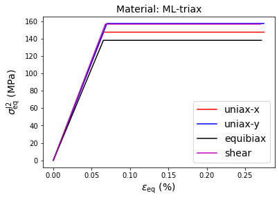

```
*** load case:  uniax-x
             Rel. error in yield strength :  0.74 %
Rel. error in plastic strain at max. load :  4.58 %
*** load case:  uniax-y
             Rel. error in yield strength :  -3.2199999999999998 %
Rel. error in plastic strain at max. load :  -0.4 %
*** load case:  equibiax
             Rel. error in yield strength :  0.8500000000000001 %
Rel. error in plastic strain at max. load :  -0.12 %
*** load case:  shear
             Rel. error in yield strength :  -2.71 %
Rel. error in plastic strain at max. load :  -1.1400000000000001 %
```

```python
fem=FE.Model(dim=2,planestress=True)
fem.geom([2, 2], LY=2.)  # define sections in absolute lengths

print('==========================================')
print('=== FEA with reference and ML material ===')
print('==========================================')
fem.assign([mat1, mat3])  # create a model with trained ML-flow rule (mat1) and reference material (mat3)
fem.bcleft(0.)
fem.bcbot(0.)
fem.bcright(0., 'force')   # free right edge
fem.bctop(0.004*fem.leny, 'disp')  # apply displacement at top nodes (uniax y-stress)
fem.mesh(NX=6, NY=3)
fem.solve()
fem.calc_global()
print('Global strain: ', np.round(fem.glob['eps'],decimals=4))
print('Element strain (ref): ', np.round(fem.element[0].eps,decimals=4))
print('Element strain (ML): ', np.round(fem.element[10].eps,decimals=4))
print('Global stress: ', np.round(fem.glob['sig'],decimals=4))
print('Element stress (ref): ', np.round(fem.element[0].sig,decimals=4))
print('Element stress (ML): ', np.round(fem.element[10].sig,decimals=4))
print('Global plastic strain: ', np.round(fem.glob['epl'],decimals=5))
print('Plastic strain (ref): ', np.round(fem.element[0].epl,decimals=5))
print('Plastic strain (ML): ', np.round(fem.element[10].epl,decimals=5))
print('----------------------------')
print('Material 1 (left section):  ',mat1.msg)
print('Material 3 (right section): ',mat3.msg)

fem.plot('stress2',mag=1)
fem.plot('seq',mag=1)
print('Note: Different definitions of SEQ for Hill and J2.')
fem.plot('peeq',mag=1)

print('\n\n====== Stress-Strain-Curves ======')
mat3.calc_properties(verb=False, eps=0.003, min_step=10)
mat3.plot_stress_strain()  # file='sigJ2-eps-ML'
for sel in mat1.prop:
    print('*** load case: ',mat1.prop[sel]['name'])
    print('             Rel. error in yield strength : ',
          100*np.round(mat3.propJ2[sel]['ys']/mat1.propJ2[sel]['ys']-1.,decimals=4),'%')
    mpl_ref = np.amax(mat1.propJ2[sel]['peeq'])
    mpl_ml1 = np.amax(mat3.propJ2[sel]['peeq'])
    print('Rel. error in plastic strain at max. load : ',
         100*np.round(mpl_ref/mpl_ml1-1.,decimals=4),'%')
```